# Final Assignment

Chuck Chekuri

3/31/2017

## Introduction

Using devices such as Jawbone Up, Nike FuelBand, and Fitbit it is now possible to collect a large amount of data about personal activity relatively inexpensively. Human Activity Recording (HAR) has generated a lot of data and many people have analyzed this data for potential applicatons like: elderly monitoring, life log systems for monitoring energy expenditure and for supporting weight-loss programs, and digital assistants for weight lifting exercises. This analysis is part of the Final Assignment for the John Hopkins Datascience Specialization course on Machine learning.

The goal is to predict the how an exercise was done by looking at the data.

### Loading required data from the web

```r
har_data <- read.csv("https://d396qusza40orc.cloudfront.net/predmachlearn/pml-training.csv", stringsAsFactors = FALSE, row.names = "X", na.strings = c("NA", "","#DIV/0!"))
test <- read.csv("https://d396qusza40orc.cloudfront.net/predmachlearn/pml-testing.csv", stringsAsFactors = FALSE, row.names = "X", na.strings = c("NA","","#DIV/0!"))
```

## Data Processing

```r
raw_predictors <- har_data[,7:158]
response <- har_data[,159]
predictors_nzv <- raw_predictors[ , apply(raw_predictors, 2,
                      function(x) !any(is.na(x)))]
```

Removing predictors with missing values yields 52 predictors. Let’s check for near zero values in the predictros.

```r
nzv <- nearZeroVar(predictors_nzv, saveMetrics = TRUE )
predictors <- predictors_nzv[c(rownames(nzv[nzv$nzv ==FALSE,])) ]
```

Search for Near Zero Values did not reduce any predictors. We still have 52 predictors.

## Predictions

We will use the 10 fold cross validaton in the caret package. With 19000 records in the training set a 10 fold cross validation takes is sufficient.

We will now build five models and create a random forest ensemble.

The five types of models are:  
- Random Forests - Linear Discriminant Analysis - High Dimension Discriminant Analysis - CART - Stochastic Gradient Boosting

#### Building the models

Below is the Accuracy results for the five models.

Below is the output of the 5 models

#### Linear Discriminant Analysis Model

```r
print(m_lda)
```

```
## Linear Discriminant Analysis
##
## 19622 samples
##    52 predictor
##     5 classes: 'A', 'B', 'C', 'D', 'E'
##
## No pre-processing
## Resampling: Cross-Validated (10 fold)
## Summary of sample sizes: 17660, 17661, 17658, 17660, 17659, 17659, ...
## Resampling results:
##
##   Accuracy   Kappa
##   0.7022206  0.6231601
##
##
```

#### High Dimension Discriminant Analysis Model

```r
print(m_hdda)
```

```
## High Dimensional Discriminant Analysis
##
## 19622 samples
##    52 predictor
##     5 classes: 'A', 'B', 'C', 'D', 'E'
##
## No pre-processing
## Resampling: Cross-Validated (10 fold)
## Summary of sample sizes: 17661, 17662, 17660, 17662, 17659, 17658, ...
## Resampling results across tuning parameters:
##
##   threshold  Accuracy   Kappa
##   0.050      0.7074728  0.6323735
##   0.175      0.5723187  0.4602374
##   0.300      0.5299693  0.4080205
##
## Tuning parameter 'model' was held constant at a value of all
## Accuracy was used to select the optimal model using  the largest value.
## The final values used for the model were threshold = 0.05 and model = all.
```

#### Random Forest

```r
print(m_rf)
```

```
## Random Forest
##
## 19622 samples
##    52 predictor
##     5 classes: 'A', 'B', 'C', 'D', 'E'
##
## No pre-processing
## Resampling: Cross-Validated (10 fold)
## Summary of sample sizes: 17659, 17661, 17658, 17659, 17661, 17659, ...
## Resampling results across tuning parameters:
##
##   mtry  Accuracy   Kappa
##    2    0.9953114  0.9940691
##   27    0.9947508  0.9933601
##   52    0.9895020  0.9867201
##
## Accuracy was used to select the optimal model using  the largest value.
## The final value used for the model was mtry = 2.
```

#### CART Model

```r
print(m_rpart)
```

```
## CART
##
## 19622 samples
##    52 predictor
##     5 classes: 'A', 'B', 'C', 'D', 'E'
##
## No pre-processing
## Resampling: Cross-Validated (10 fold)
## Summary of sample sizes: 17660, 17659, 17661, 17659, 17660, 17659, ...
## Resampling results across tuning parameters:
##
##   cp           Accuracy   Kappa
##   0.000000000  0.9400155  0.92411833
##   0.001163177  0.8980225  0.87094412
##   0.002326354  0.8590858  0.82173610
##   0.003489531  0.8205065  0.77284970
##   0.004652709  0.8075620  0.75653842
##   0.005815886  0.8005288  0.74766637
##   0.006979063  0.7798879  0.72125316
##   0.008142240  0.7646502  0.70163997
##   0.009305417  0.7512983  0.68470409
##   0.010468594  0.7335121  0.66170545
##   0.011631771  0.6944216  0.61397671
##   0.012794948  0.6934028  0.61260328
##   0.013958126  0.6803067  0.59693260
##   0.015121303  0.6803067  0.59693260
##   0.016284480  0.6791859  0.59553534
##   0.017447657  0.6692479  0.58324372
##   0.018610834  0.6649157  0.57795584
##   0.019774011  0.6546216  0.56543361
##   0.020937188  0.6279168  0.53281857
##   0.022100366  0.5662122  0.43994875
##   0.023263543  0.5407706  0.40157034
##   0.024426720  0.5407706  0.40157034
##   0.025589897  0.5407706  0.40157034
##   0.026753074  0.5407706  0.40157034
##   0.027916251  0.5407706  0.40157034
##   0.029079428  0.5378654  0.39767081
##   0.030242606  0.5245637  0.37981400
##   0.031405783  0.5193656  0.37278664
```

[output cut: 60 more lines]

```
##   0.102359588  0.3667816  0.12545200
##   0.103522765  0.3667816  0.12545200
##   0.104685942  0.3667816  0.12545200
##   0.105849119  0.3667816  0.12545200
##   0.107012296  0.3667816  0.12545200
##   0.108175474  0.3667816  0.12545200
##   0.109338651  0.3667816  0.12545200
##   0.110501828  0.3667816  0.12545200
##   0.111665005  0.3667816  0.12545200
##   0.112828182  0.3667816  0.12545200
##   0.113991359  0.3667816  0.12545200
##   0.115154536  0.3238751  0.06020486
##
## Accuracy was used to select the optimal model using  the largest value.
## The final value used for the model was cp = 0.
```

#### Stochastic Gradient Boosting

```r
print(m_gbm)
```

```
## Stochastic Gradient Boosting
##
## 19622 samples
##    52 predictor
##     5 classes: 'A', 'B', 'C', 'D', 'E'
##
## No pre-processing
## Resampling: Cross-Validated (10 fold)
## Summary of sample sizes: 17660, 17659, 17661, 17658, 17659, 17662, ...
## Resampling results:
##
##   Accuracy   Kappa
##   0.9938853  0.9922653
##
## Tuning parameter 'n.trees' was held constant at a value of 150
##  10
## Tuning parameter 'shrinkage' was held constant at a value of
##  0.1
## Tuning parameter 'n.minobsinnode' was held constant at a value of 10
##
```

Gradiant Boostig Machine and Random Forests give the most accurate prediction of 0.9938853 and 0.9953114 respectively as can be seen below table and chart

```r
results <- resamples(models)
summary(results)
```

```
##
## Call:
## summary.resamples(object = results)
##
## Models: Random Forest, Linear Discriminant Analysis, High Dimension Discriminant Analysis, CART, Stochasting Gradient Boosting
## Number of resamples: 10
##
## Accuracy
##                                        Min. 1st Qu. Median   Mean 3rd Qu.
## Random Forest                        0.9939  0.9945 0.9952 0.9953  0.9959
## Linear Discriminant Analysis         0.6860  0.6962 0.7019 0.7022  0.7069
## High Dimension Discriminant Analysis 0.6999  0.7028 0.7054 0.7075  0.7107
## CART                                 0.9276  0.9393 0.9419 0.9400  0.9440
## Stochasting Gradient Boosting        0.9893  0.9935 0.9939 0.9939  0.9944
##                                        Max. NA's
## Random Forest                        0.9969    0
## Linear Discriminant Analysis         0.7205    0
## High Dimension Discriminant Analysis 0.7214    0
## CART                                 0.9470    0
## Stochasting Gradient Boosting        0.9975    0
##
## Kappa
##                                        Min. 1st Qu. Median   Mean 3rd Qu.
## Random Forest                        0.9923  0.9931 0.9939 0.9941  0.9948
## Linear Discriminant Analysis         0.6027  0.6157 0.6227 0.6232  0.6290
## High Dimension Discriminant Analysis 0.6233  0.6261 0.6300 0.6324  0.6365
## CART                                 0.9084  0.9233 0.9265 0.9241  0.9291
## Stochasting Gradient Boosting        0.9865  0.9918 0.9923 0.9923  0.9929
##                                        Max. NA's
## Random Forest                        0.9961    0
## Linear Discriminant Analysis         0.6466    0
## High Dimension Discriminant Analysis 0.6500    0
## CART                                 0.9329    0
## Stochasting Gradient Boosting        0.9968    0
```

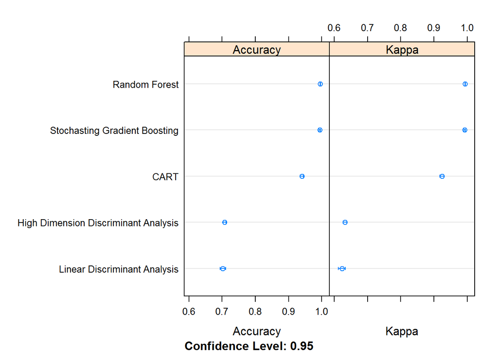

```r
dotplot(results)
```

## Build an ensemble

```r
# create a random sample of 100  predictions to build an ensemble  rf model
stackSample <- df[sample(1:nrow(df), size=100),]
s_rf    <- predict(models[[1]], stackSample)
s_lda   <- predict(models[[2]], stackSample)
s_hdda  <- predict(models[[3]], stackSample)
s_rpart <- predict(models[[4]], stackSample)
s_gbm   <- predict(models[[5]], stackSample)
# stack using rf
stackDf <- data.frame(m1=s_rf, m2=s_lda, m3=s_hdda,
                      m4=s_rpart, m5=s_gbm,
                      classe = stackSample$classe)
```

Here is the data from for the predictions from all 5 Models and the building of the ensemble model

```r
head(stackDf)
```

```
##   m1 m2 m3 m4 m5 classe
## 1  C  D  C  C  C      C
## 2  A  A  A  A  A      A
## 3  D  D  D  D  D      D
## 4  D  D  D  D  D      D
## 5  B  B  B  B  B      B
## 6  A  A  A  A  A      A
```

```r
rf_fit <- train(classe ~ ., method = "rf", data = stackDf)
print(rf_fit)
```

```
## Random Forest
##
## 100 samples
##   5 predictor
##   5 classes: 'A', 'B', 'C', 'D', 'E'
##
## No pre-processing
## Resampling: Bootstrapped (25 reps)
## Summary of sample sizes: 100, 100, 100, 100, 100, 100, ...
## Resampling results across tuning parameters:
##
##   mtry  Accuracy  Kappa
##    2    1         1
##   11    1         1
##   20    1         1
##
## Accuracy was used to select the optimal model using  the largest value.
## The final value used for the model was mtry = 2.
```

The ensemble model has an accuracy 1 , which is better than any of the submodels.

## Predictions

```r
p_rf    <- predict(models[[1]], test)
p_lda   <- predict(models[[2]], test)
p_hdda  <- predict(models[[3]], test)
p_rpart <- predict(models[[4]], test)
p_gbm   <- predict(models[[5]], test)
finalSubPreds <- data.frame(m1=p_rf, m2=p_lda, m3=p_hdda, m4=p_rpart, m5=p_gbm)
finalPredictions <- predict(rf_fit, finalSubPreds)
finalPredictions
```

```
##  [1] B A B A A E D B A A B C B A E E A B B B
## Levels: A B C D E
```

The final predictions for the 20 samples are: B, A, B, A, A, E, D, B, A, A, B, C, B, A, E, E, A, B, B, B

### References

Ugulino, W.; Cardador, D.; Vega, K.; Velloso, E.; Milidiu, R.; Fuks, H. Wearable Computing: Accelerometers’ Data Classification of Body Postures and Movements. Proceedings of 21st Brazilian Symposium on Artificial Intelligence. Advances in Artificial Intelligence - SBIA 2012. In: Lecture Notes in Computer Science. , pp. 52-61. Curitiba, PR: Springer Berlin / Heidelberg, 2012. ISBN 978-3-642-34458-9. DOI: 10.1007/978-3-642-34459-6_6. [Read more here](http://groupware.les.inf.puc-rio.br/har#sbia_paper_section#ixzz4cvTsKQLB)